# IODS-Final

Tuure Parviainen

December 13, 2017

# IODS-Final: Boston dataset

I completed all the DataCamp exercises prior to proceeding to this exercise. I also looked up some details how to use the RMarkdown more productively and hopefully this report will be clearer than the previous ones. This is the final assignment. This course has been quite fun and I feel I have learned a lot.

### Abstract

Today we are looking at the Boston **nitrogen oxides concentration**.

We know from the previous analysis that nitrogen oxides concentration is connected with the variables in the dataset.

### Boston Data set information:

| Variables | Description |
| --- | --- |
| crim | per capita crime rate by town. |
| zn | proportion of residential land zoned for lots over 25,000 sq.ft. |
| indus | proportion of non-retail business acres per town. |
| chas | Charles River dummy variable (= 1 if tract bounds river; 0 otherwise). |
| nox | nitrogen oxides concentration (parts per 10 million). |
| rm | average number of rooms per dwelling. |
| age | proportion of owner-occupied units built prior to 1940. |
| dis | weighted mean of distances to five Boston employment centres. |
| rad | index of accessibility to radial highways. |
| tax | full-value property-tax rate per $10,000. |
| ptratio | pupil-teacher ratio by town. |
| black | 1000(Bk - 0.63)^2 where Bk is the proportion of blacks by town. |
| lstat | lower status of the population (percent). |
| medv | median value of owner-occupied homes divided by $1000s. |

Based from this [source.](https://www.cs.toronto.edu/~delve/data/boston/bostonDetail.html) The dataset is derived from information collected by the U.S. Census Service concerning housing in the area of Boston Mass.

The data was originally published by Harrison, D. and Rubinfeld, D.L. `Hedonic prices and the demand for clean air’, J. Environ. Economics & Management, vol.5, 81-102, 1978.

All variables are numeric variables except “chas”, “rad” “tax”. The data has demographical data of Boston (N = 506) including tax and several variables possibly linked to housing values within the city. However, in the previous exercise we found that nitrogen oxide concentration is linked to crime and other demographic variables, so we are going to explore how they are linked. In the [data preparation](https://github.com/toparvia/IODS-final/blob/master/IODS-final_dataprep.TP.r) we looked at the normality assumption of the data and found out that “crim”, per capita crime rate might benefit from square transformation. Therefore the data is divided into three different datasets, which are further divided with random sample to train (70%) and tests (30%) datasets.

1. Normal unchanged dataset
   - 1a Normal train
   - 1b Normal test
2. Scaled dataset
   - 2a Scaled train
   - 2b Scaled test
3. Scaled dataset with the “crim” variable transformed with the square transformation
   - 3a transformed and scaled train
   - 3b transformed and scaled test

## Data exploration

```r
knitr::opts_chunk$set(echo = TRUE, warning=FALSE)
require("easypackages") # for loading and installing many packages at one time
packages_to_load <- c("broom", "dplyr", "tidyverse", "corrplot", "ggplot2", "GGally", "caret", "devtools", "ggthemes", "scales", "reshape2","MASS", "ggpubr","WVPlots")
packages(packages_to_load, prompt = TRUE) # lock'n'load install/load
```

```r
# set the seed to make your partition reproductible
set.seed(777)

# 1) Normal unchanged dataset
boston <- read.table("data/boston.txt")

# 70% of the sample size
sample_size <- floor(0.70 * nrow(boston))

train_ind <- sample(seq_len(nrow(boston)), size = sample_size)
# splitting data by the vector
trainb <- boston[train_ind, ]
testb <- boston[-train_ind, ]

# 2) Scaled dataset
bostons <- read.table("data/bostons.txt")
# 70% of the sample size

train_inds <- sample(seq_len(nrow(bostons)), size = sample_size)
# splitting data by the vector
trainbs <- bostons[train_inds, ]
testbs <- bostons[-train_inds, ]


# 3) Scaled dataset with the crim transformed with the square transformation (log can't deal with zeros).
bostonssq <- read.table("data/bostonssq.txt")
# General note: It seems that some of the data has been censored for the high tax category
# 70% of the sample size

train_indssq <- sample(seq_len(nrow(bostonssq)), size = sample_size)
# splitting data by the vector
trainbssq <- bostonssq[train_indssq, ]
testbssq <- bostonssq[-train_indssq, ]
```

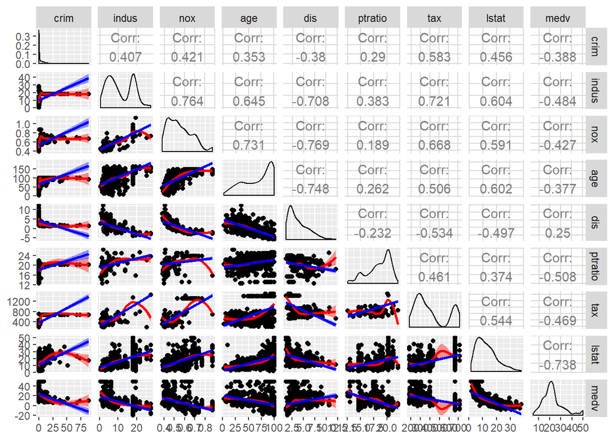

```r
my_fn <- function(data, mapping, ...){
  p <- ggplot(data = data, mapping = mapping) +
    geom_point() +
    geom_smooth(method=loess, fill="red", color="red", ...) +
    geom_smooth(method=lm, fill="blue", color="blue", ...)
  p
}
g = ggpairs(boston,columns = c(1,3,5,7,8,11,10,13:14), lower = list(continuous = my_fn))
g
```

Selected variables for closer inspection. Blue line is linear regression between variables and red is LOESS smoother (locally weighted scatterplot smoothing)

1. It seems that indus, nox, rad, tax and lstat have positive correlation with crime, and dis, black and medv have negative correlation with crime.
2. Many of the variables seems to have non-linear relationships (red lines in the picture), however the variables with high correlation seems to be more linear.

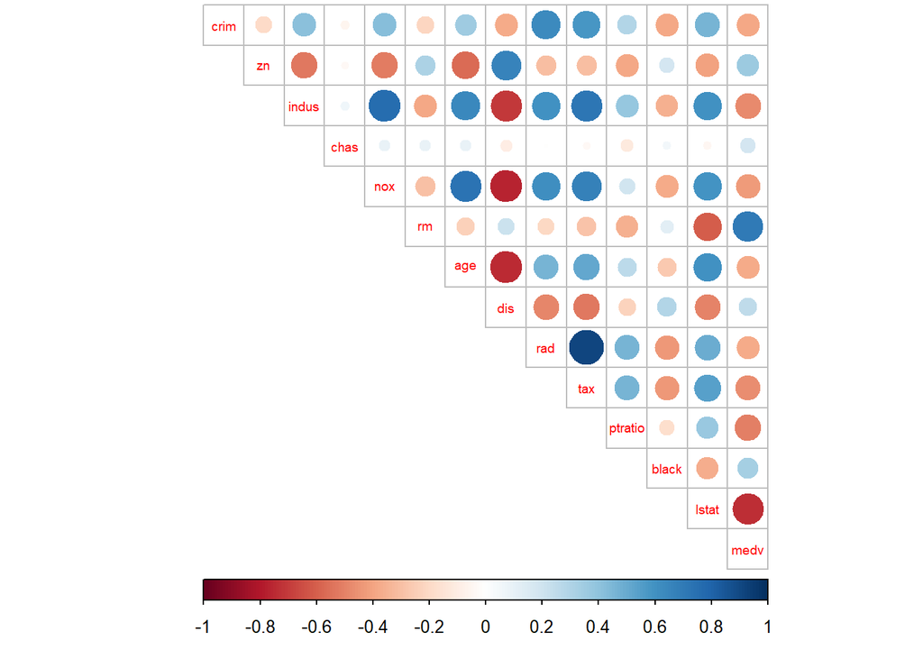

```r
# calculate the correlation matrix and round it
cor_matrix<-cor(boston) %>% round(digits = 2)

# visualize the correlation matrix
corrplot(cor_matrix, method="circle", type = "upper", cl.pos = "b", tl.pos = "d", tl.cex = 0.6)
```

Variable correlation, since not all were plotted in previous picture. Nitrous oxide concentration has **0.5> positive correlation** with age: proportion of owner-occupied units built prior to 1940, rad: index of accessibility to radial highways, tax: full-value property-tax rate per $10,000, lstat: lower status of the population (percent). **-0.5 < Negative correlation** with dis: weighted mean of distances to five Boston employment centres. These seem to be reasonable relatioships to continue with more in-depth analysis.

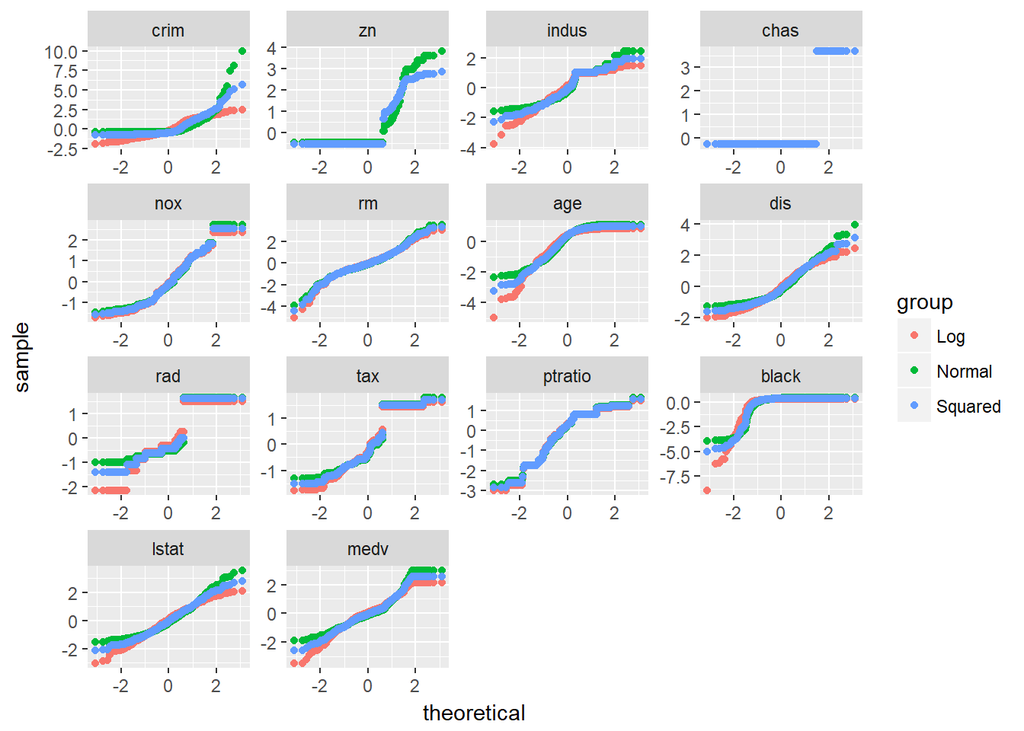

```r
# We will compare two different transformations for data. Log and square root transformation.
BostonSq <- sqrt(boston) %>% scale() %>% as.data.frame() %>%  melt()
BostonSq$group <- "Squared"
BostonL <- log(boston) %>% scale() %>% as.data.frame() %>%  melt()
BostonL$group <- "Log"
BostonN <- boston %>% scale() %>% as.data.frame() %>%  melt()
BostonN$group <- "Normal"

BostonGraph <- rbind(BostonSq, BostonL, BostonN)
BostonGraph <-BostonGraph[complete.cases(BostonGraph),]

# Here we plot all the distributions to a QQ plots
ggplot(data = BostonGraph, mapping = aes(sample = value)) +
  stat_qq(aes(color=group)) + facet_wrap(~variable, scales = 'free')
```

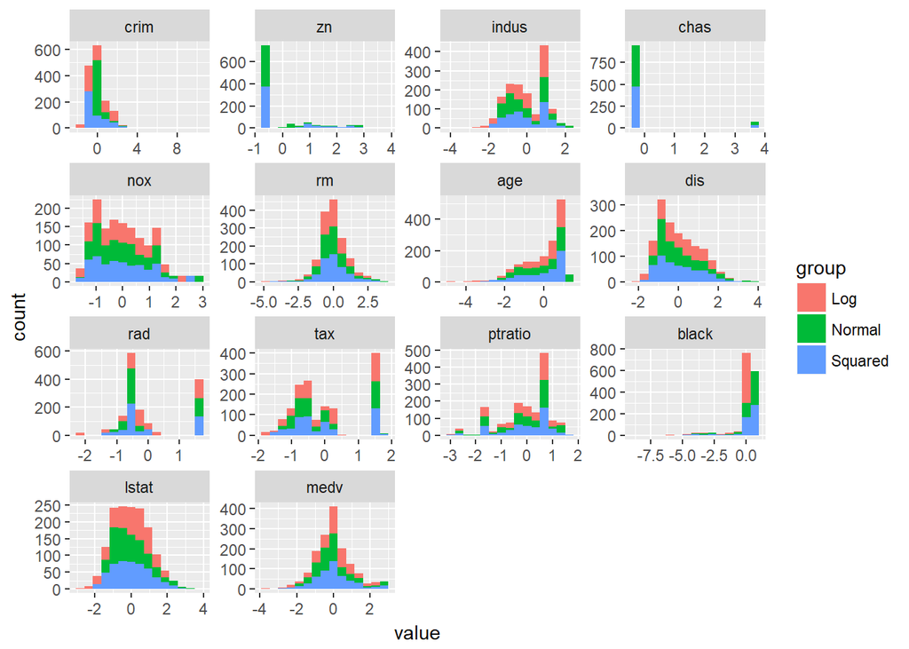

```r
# Here we plot are histograms so we can evaluate the impact to the variables
ggplot(data = BostonGraph, mapping = aes(x = value)) +
  geom_histogram(aes(fill=group),bins = 15) + facet_wrap(~variable, scales = 'free')
```